## Задание1.Загрузите датасет insurance_cost.csv (лежит в папке домашнего задания). Это

данные по базовым показателям здоровья индивида и сумме, которую страховая компания заплатила за его лечение в год.

```r
# Загружаем датасет
insurance_data <- read.csv("C:/Users/tanya/Downloads/insurance_cost.csv")



head(insurance_data)
```

```
##   age    sex    bmi children smoker    region   charges
## 1  19 female 27.900        0    yes southwest 16884.924
## 2  18   male 33.770        1     no southeast  1725.552
## 3  28   male 33.000        3     no southeast  4449.462
## 4  33   male 22.705        0     no northwest 21984.471
## 5  32   male 28.880        0     no northwest  3866.855
## 6  31 female 25.740        0     no southeast  3756.622
```

```r
summary(insurance_data)
```

```
##       age            sex                 bmi           children
##  Min.   :18.00   Length:1338        Min.   :15.96   Min.   :0.000
##  1st Qu.:27.00   Class :character   1st Qu.:26.30   1st Qu.:0.000
##  Median :39.00   Mode  :character   Median :30.40   Median :1.000
##  Mean   :39.21                      Mean   :30.66   Mean   :1.095
##  3rd Qu.:51.00                      3rd Qu.:34.69   3rd Qu.:2.000
##  Max.   :64.00                      Max.   :53.13   Max.   :5.000
##     smoker             region             charges
##  Length:1338        Length:1338        Min.   : 1122
##  Class :character   Class :character   1st Qu.: 4740
##  Mode  :character   Mode  :character   Median : 9382
##                                        Mean   :13270
##                                        3rd Qu.:16640
##                                        Max.   :63770
```

```r
str(insurance_data)
```

```
## 'data.frame':    1338 obs. of  7 variables:
##  $ age     : int  19 18 28 33 32 31 46 37 37 60 ...
##  $ sex     : chr  "female" "male" "male" "male" ...
##  $ bmi     : num  27.9 33.8 33 22.7 28.9 ...
##  $ children: int  0 1 3 0 0 0 1 3 2 0 ...
##  $ smoker  : chr  "yes" "no" "no" "no" ...
##  $ region  : chr  "southwest" "southeast" "southeast" "northwest" ...
##  $ charges : num  16885 1726 4449 21984 3867 ...
```

#Задание 2. Выведите гистограммы всех нумерических переменных.

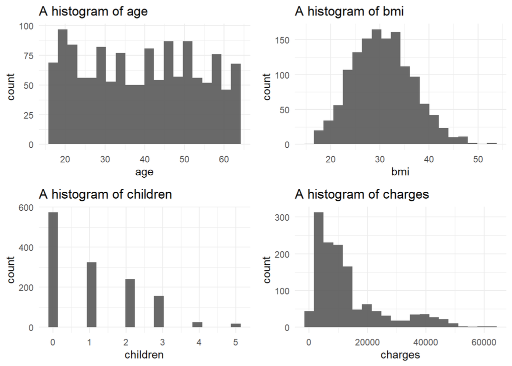

```r
library(tidyverse)

graph_num <- function(num_var) {
  ggplot(insurance_data) +
    geom_histogram(aes(x = .data[[num_var]]), alpha = 0.9, bins = 20) +
    labs(title = glue("A histogram of {num_var}")) +
    theme_minimal()
}

numeric_vars <- names(insurance_data)[sapply(insurance_data, is.numeric)]

graph_num_list <- map(numeric_vars, ~graph_num(.x))

grid.arrange(grobs = graph_num_list, ncol = 2)  # Для вывода гистограмм в несколько столбцов
```

#Задание 3.Нарисуйте график плотности по колонке charges. Отметьте вертикальные линиисредней и медианы на графике. Раскрасьте текст и линии средней и медианы разными цветами. Добавьте текстовые пояснения значения средней и медианы. Подберите тему для графика. Назовите оси.

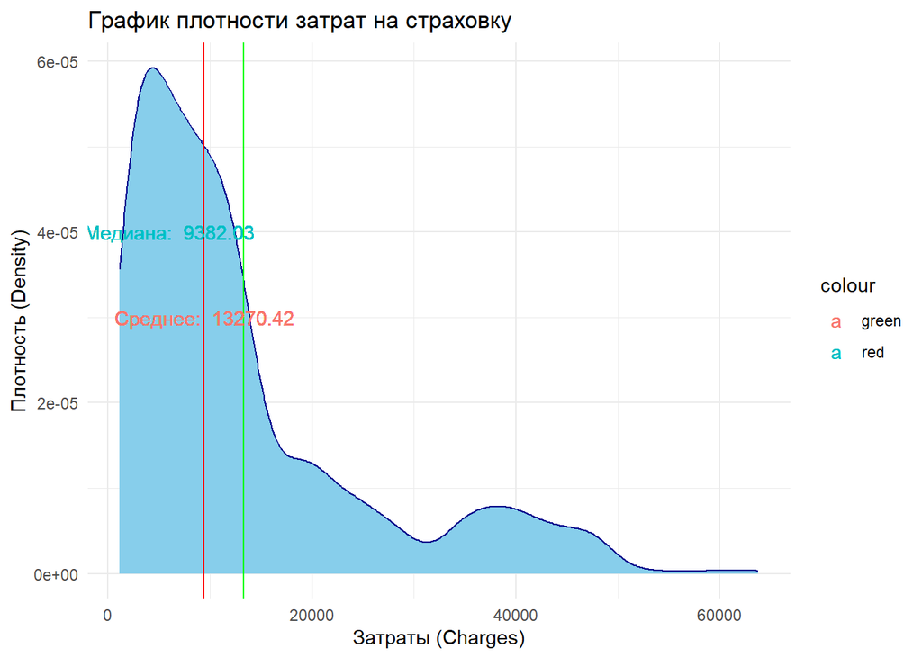

```r
# Устанавливаем тему для графика
theme_set(theme_minimal())

p <- ggplot(insurance_data, aes(x = charges)) +
  geom_density(fill = "skyblue", color = "darkblue") +
  labs(x = "Затраты (Charges)", y = "Плотность (Density)") +
  ggtitle("График плотности затрат на страховку") +

  # Вертикальная линия для медианы
  geom_vline(aes(xintercept = median(charges)), color = "red") +
  geom_text(aes(x = median(charges) + 5000, y = 0.00004, label = paste("Медиана: ", round(median(charges), 2)), color = "red"), hjust = 1) +

  # Вертикальная линия для среднего
  geom_vline(aes(xintercept = mean(charges)), color = "green") +
  geom_text(aes(x = mean(charges) + 5000, y = 0.00003, label = paste("Среднее: ", round(mean(charges), 2)), color = "green"), hjust = 1)

print(p)
```

#задание 4 Сделайте три box_plot по отношению переменных charges и (1) sex (2) smoker (3) region. Подберите тему для графика. Назовите оси.

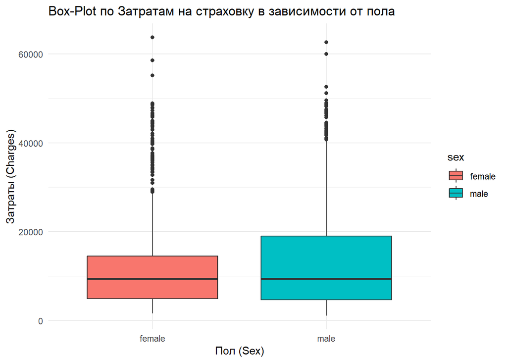

```r
# Устанавливаем тему для графиков
theme_set(theme_minimal())

# Box-plot по переменной "charges" и "sex"
boxplot_sex <- ggplot(insurance_data, aes(x = sex, y = charges, fill = sex)) +
  geom_boxplot() +
  labs(x = "Пол (Sex)", y = "Затраты (Charges)") +
  ggtitle("Box-Plot по Затратам на страховку в зависимости от пола")

# Box-plot по переменной "charges" и "smoker"
boxplot_smoker <- ggplot(insurance_data, aes(x = smoker, y = charges, fill = smoker)) +
  geom_boxplot() +
  labs(x = "Курение (Smoker)", y = "Затраты (Charges)") +
  ggtitle("Box-Plot по Затратам на страховку в зависимости от курения")

# Box-plot по переменной "charges" и "region"
boxplot_region <- ggplot(insurance_data, aes(x = region, y = charges, fill = region)) +
  geom_boxplot() +
  labs(x = "Регион (Region)", y = "Затраты (Charges)") +
  ggtitle("Box-Plot по Затратам на страховку в зависимости от региона")

# Выводим графики
print(boxplot_sex)
```

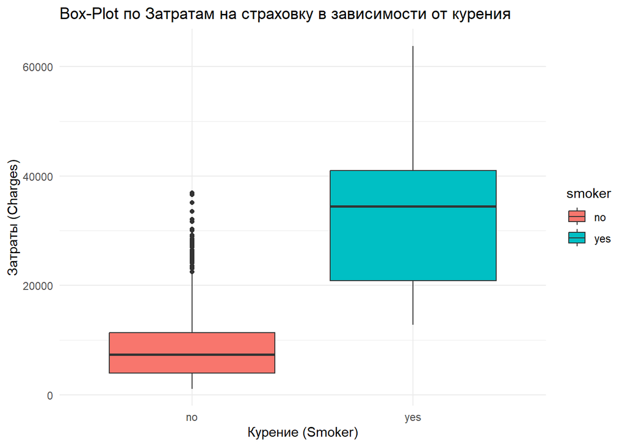

```r
print(boxplot_smoker)
```

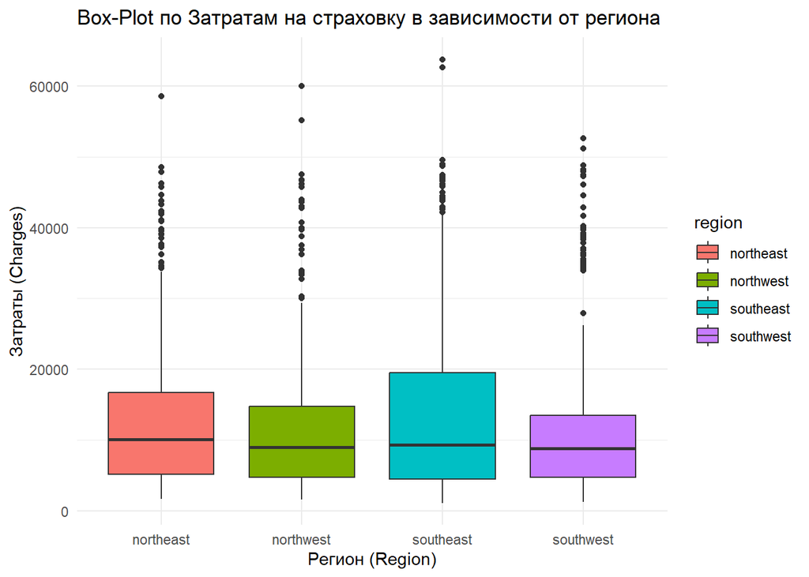

```r
print(boxplot_region)
```

#Задание 5

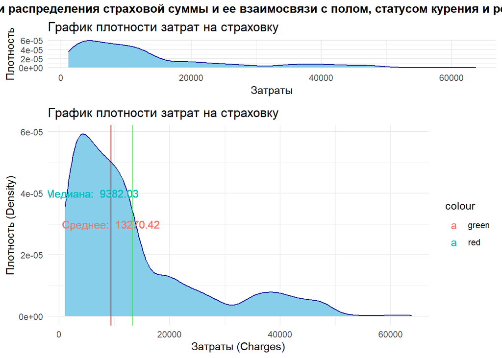

```r
# Создаем графики Box Plot для пола, курения и региона
p_sex <- ggplot(insurance_data, aes(x = sex, y = charges, fill = sex)) +
  geom_boxplot() +
  labs(x = "Пол", y = "Затраты") +
  ggtitle("Box Plot по Затратам на страховку в зависимости от пола")

p_smoker <- ggplot(insurance_data, aes(x = smoker, y = charges, fill = smoker)) +
  geom_boxplot() +
  labs(x = "Курение", y = "Затраты") +
  ggtitle("Box Plot по Затратам на страховку в зависимости от курения")

p_region <- ggplot(insurance_data, aes(x = region, y = charges, fill = region)) +
  geom_boxplot() +
  labs(x = "Регион", y = "Затраты") +
  ggtitle("Box Plot по Затратам на страховку в зависимости от региона")

# Создаем график плотности затрат
p_charges <- ggplot(insurance_data, aes(x = charges)) +
  geom_density(fill = "skyblue", color = "darkblue") +
  labs(x = "Затраты", y = "Плотность") +
  ggtitle("График плотности затрат на страховку")

# Создаем макет графиков с регулированием размеров
combine_plots <- ggarrange(
  p_charges, p, ncol = 1, nrow = 2,
  widths = c(1, 4),
  heights = c(1, 3)
) |>
annotate_figure(top = text_grob("Графики распределения страховой суммы и ее взаимосвязи с полом, статусом курения и регионом", face = "bold"))

# Выводим график
combine_plots
```

#Задание 6.Сделайте фасет графика из задания 3 по колонке region.

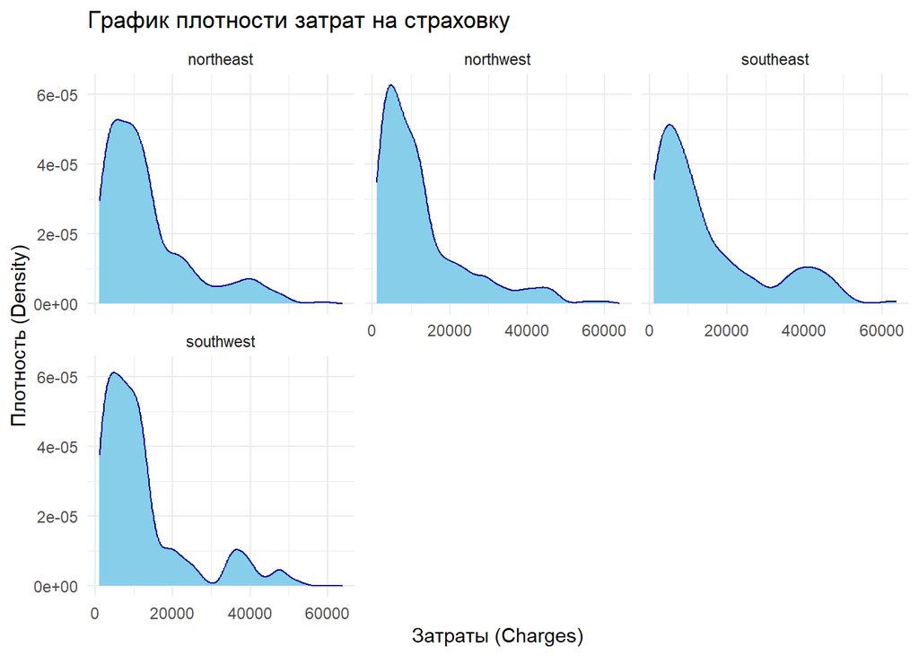

```r
# Устанавливаем тему для графиков
theme_set(theme_minimal())

# График из задания 3 (Density Plot) с фасетами по "region"
density_plot <- ggplot(insurance_data, aes(x = charges)) +
  geom_density(fill = "skyblue", color = "darkblue") +
  labs(x = "Затраты (Charges)", y = "Плотность (Density)") +
  ggtitle("График плотности затрат на страховку") +
  facet_wrap(~ region, ncol = 3)  # Разделяем по колонке "region" с 3 столбцами

# Выводим график
print(density_plot)
```

#Задание 7.Постройте scatter plot отношения переменных age и charges. Добавьте названия осей, название графика и тему. Сделайте так, чтобы числа по оси Х отображались 14 шрифтом.

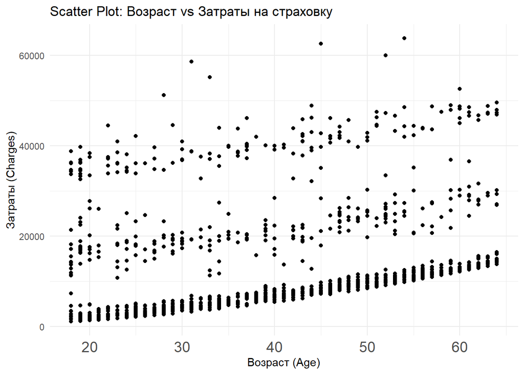

```r
library(ggplot2)

# Создаем scatter plot
scatter_plot <- ggplot(insurance_data, aes(x = age, y = charges)) +
  geom_point() +  # Отображаем точки
  labs(x = "Возраст (Age)", y = "Затраты (Charges)") +  # Добавляем названия осей
  ggtitle("Scatter Plot: Возраст vs Затраты на страховку") +  # Название графика
  theme_minimal() +  # Устанавливаем тему "minimal"
  theme(axis.text.x = element_text(size = 14) )  # Размер шрифта чисел по оси X

# Выводим график
print(scatter_plot)
```

#Задание 8.Проведите линию тренда для предыдущего графика.

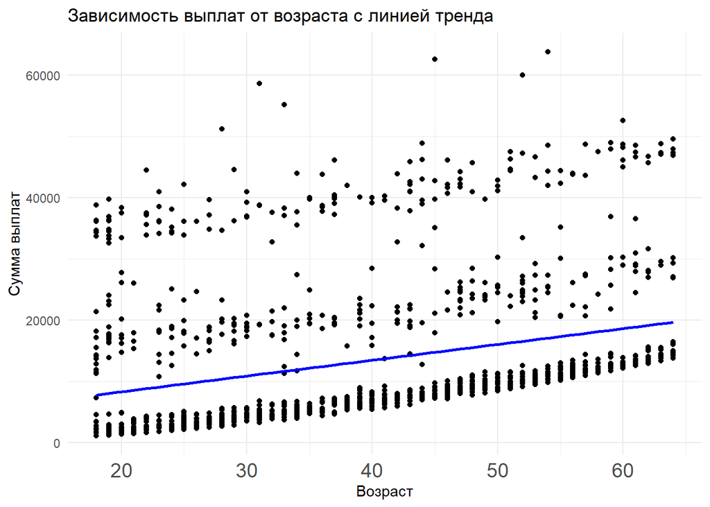

```r
ggplot(data = insurance_data, aes(x = age, y = charges)) +
  geom_point() +
  geom_smooth(method = "lm", se = FALSE, color = "blue") +  # Добавление линии тренда (линейной регрессии)
  xlab("Возраст") +
  ylab("Сумма выплат") +
  ggtitle("Зависимость выплат от возраста с линией тренда") +
  theme(axis.text.x = element_text(size = 14))
```

#Задание 9.Сделайте разбивку предыдущего графика по колонке smokers (у вас должно получится две линии тренда для курящих и нет).

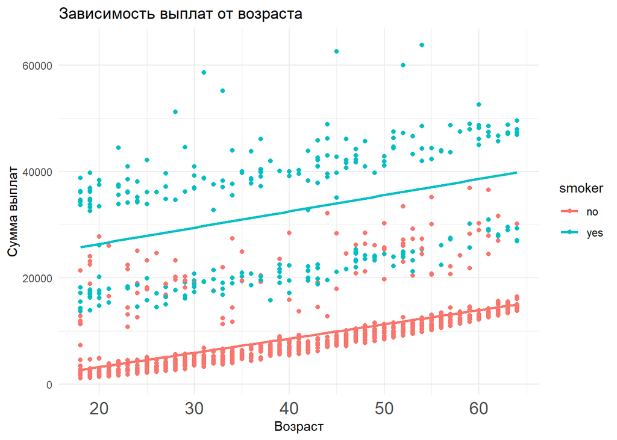

```r
ggplot(data = insurance_data, aes(x = age, y = charges, group = smoker, color = smoker)) +
  geom_point() +
  geom_smooth(method = "lm", se = FALSE) +
  xlab("Возраст") +
  ylab("Сумма выплат") +
  ggtitle("Зависимость выплат от возраста") +
  theme(axis.text.x = element_text(size = 14))
```

#Задание 10. Сделайте график из заданий 7-9, но вместо переменной age используйте переменную bmi.

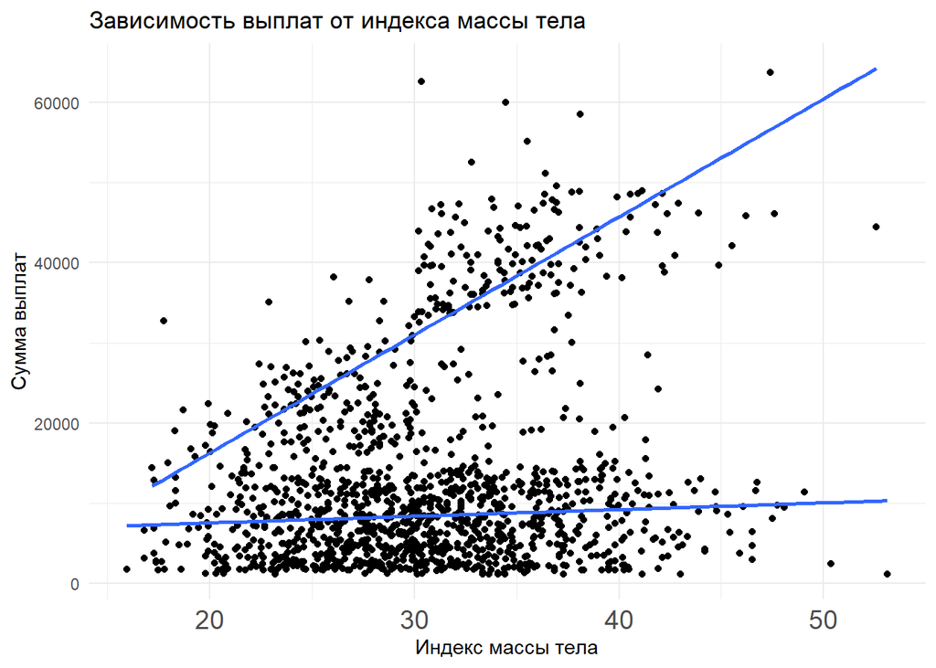

```r
ggplot(data = insurance_data, aes(x = bmi, y = charges, group = smoker)) +
  geom_point() +
  geom_smooth(method = "lm", se = FALSE) +
  xlab("Индекс массы тела") +
  ylab("Сумма выплат") +
  ggtitle("Зависимость выплат от индекса массы тела") +
  theme(axis.text.x = element_text(size = 14))
```

#Задание 11 Как различаются затраты на страховку (charges) между курящими (smoker) и некурящими (non-smoker) женщинами (gender) в возрастной группе от 30 до 50 лет? Выбираю Box-plot потому что подходит для визуализации различий между категориями и позволяет увидеть медиану, квартили и выбросы данных.

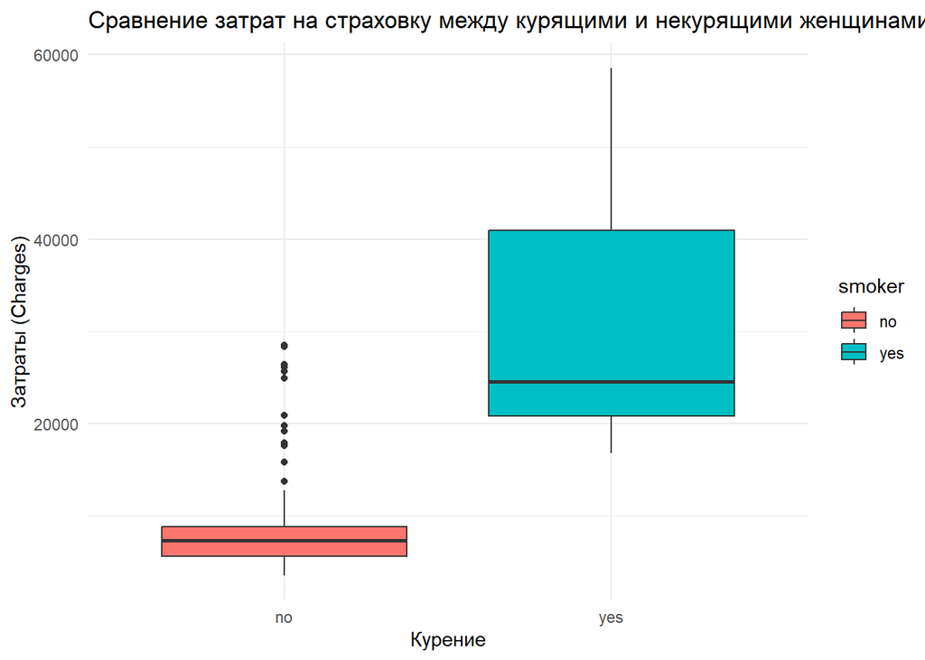

```r
# Создаем подвыборку данных для женщин в возрастной группе от 30 до 50 лет
subsample <- subset(insurance_data, sex == "female" & age >= 30 & age <= 50)

# Создаем box-plot график для затрат на страховку с разделением по курению
boxplot <- ggplot(subsample, aes(x = smoker, y = charges, fill = smoker)) +
  geom_boxplot() +
  labs(x = "Курение", y = "Затраты (Charges)") +
  ggtitle("Сравнение затрат на страховку между курящими и некурящими женщинами в возрасте от 30 до 50 лет") +
  theme_minimal()

# Выводим график
print(boxplot)
```

#Задание 12. Как распределяются затраты на страховку (charges) среди людей с различным количеством детей (children)? Есть ли разница в затратах между семьями с детьми и без детей? Выбирала boxplot по той же причине.

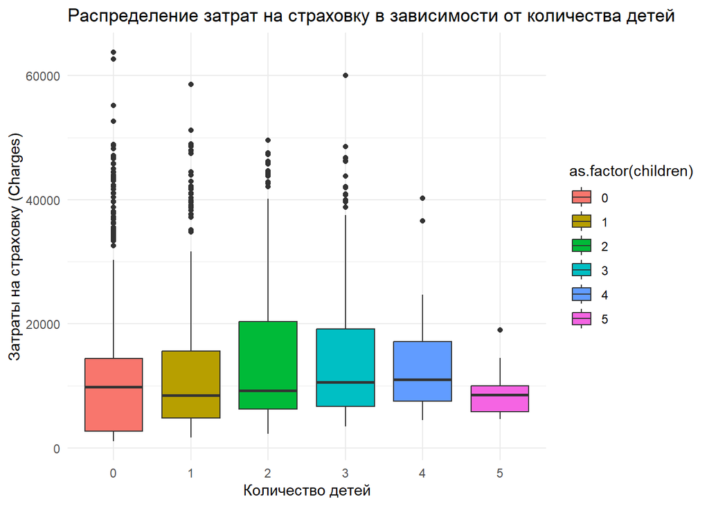

```r
# Создаем box-plot для распределения затрат на страховку в зависимости от количества детей
boxplot <- ggplot(insurance_data, aes(x = as.factor(children), y = charges, fill = as.factor(children))) +
  geom_boxplot() +
  labs(x = "Количество детей", y = "Затраты на страховку (Charges)") +
  ggtitle("Распределение затрат на страховку в зависимости от количества детей") +
  theme_minimal()

# Выводим график
print(boxplot)
```

#Задание 13.Как варьируется индекс массы тела (bmi) в зависимости от возраста у курящих женщин? Линейный график подойдет для визуализации этой связи, так как он позволяет наглядно отобразить изменения переменнойпо мере изменения другой переменной.

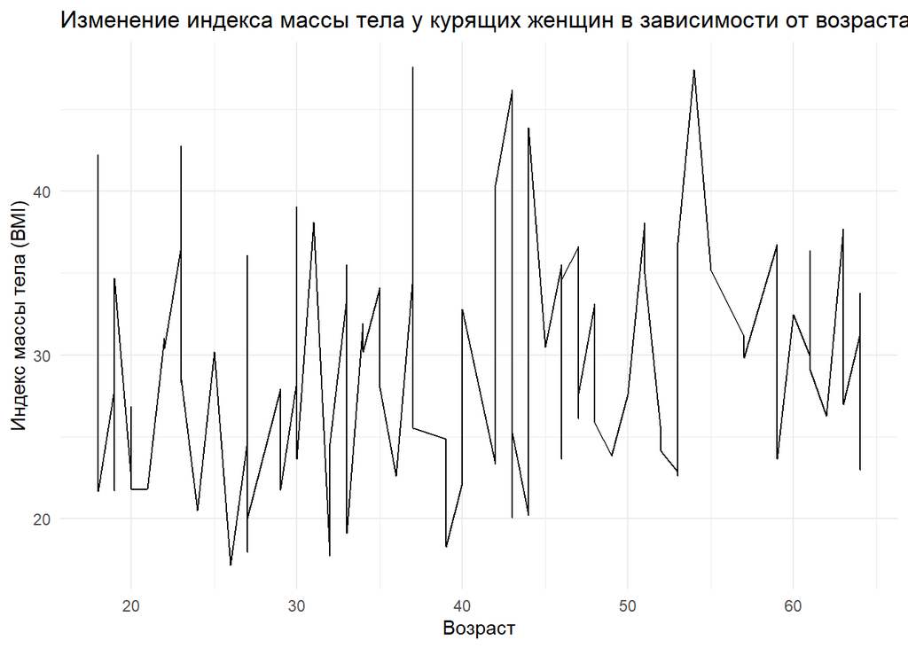

```r
# Создаем подвыборку данных для курящих женщин
subsample <- subset(insurance_data, sex == "female" & smoker == "yes")

# Создаем линейный график изменения индекса массы тела (bmi) в зависимости от возраста
line_plot <- ggplot(subsample, aes(x = age, y = bmi)) +
  geom_line() +
  labs(x = "Возраст", y = "Индекс массы тела (BMI)") +
  ggtitle("Изменение индекса массы тела у курящих женщин в зависимости от возраста") +
  theme_minimal()

# Выводим график
print(line_plot)
```

#Задание 14

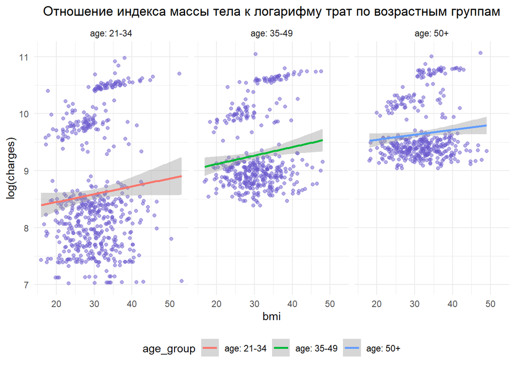

```r
# Создаем возрастные группы
insurance_data <- insurance_data %>%
  mutate(age_group = case_when(
    age < 35 ~ "age: 21-34",
    age >= 35 & age < 50 ~ "age: 35-49",
    age >= 50 ~ "age: 50+"
  ))


# Создаем график
plot <- ggplot(insurance_data, aes(x = bmi, y = log(charges), color = age_group)) +
  facet_wrap(~age_group) +  # Разбиваем на подграфики по возрастным группам
  geom_point(fill = "#6A5ACD", color = "#6A5ACD", alpha = 0.5) +  # Отображаем точки
  geom_smooth(method = lm) +  # Добавляем линии тренда
  ggtitle("Отношение индекса массы тела к логарифму трат по возрастным группам") +  # Название графика
  theme_minimal() +  # Устанавливаем минимальную тему
  theme(legend.position = "bottom", plot.title = element_text(hjust = 0.5))  # Устанавливаем положение легенды и заголовка графика

# Выводим график
print(plot)
```